# Discrimination tests and the Thurstonian model

Block 3 · exercises 13 – 14

Sensometrics in R · SaIT

## The problem: 42% is not always 42%

- Triangle: 42 of 100 correct answers
- 2-AFC: 76 of 100 correct answers

Which product differs more from the control?

**Equally.** Both results correspond to the same difference between samples. The proportion of correct answers depends on the **method**, not only on the samples.

## The Thurstonian model

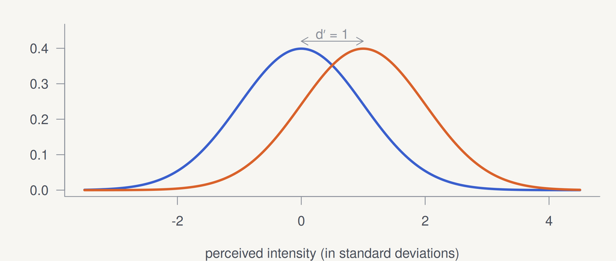

```r
z <- seq(-3.5, 4.5, length.out = 300)
plot(z, dnorm(z), type = "l", lwd = 3, col = pal[3], ylim = c(0, 0.45),
     xlab = "perceived intensity (in standard deviations)", ylab = "")
lines(z, dnorm(z, mean = 1), lwd = 3, col = pal[2])
arrows(0, 0.42, 1, 0.42, code = 3, length = 0.1); text(0.5, 0.44, "d′ = 1")
```

Perception varies from tasting to tasting. **d′** = the distance between two distributions in standard deviations – a measure of difference independent of the method.

## Psychometric functions

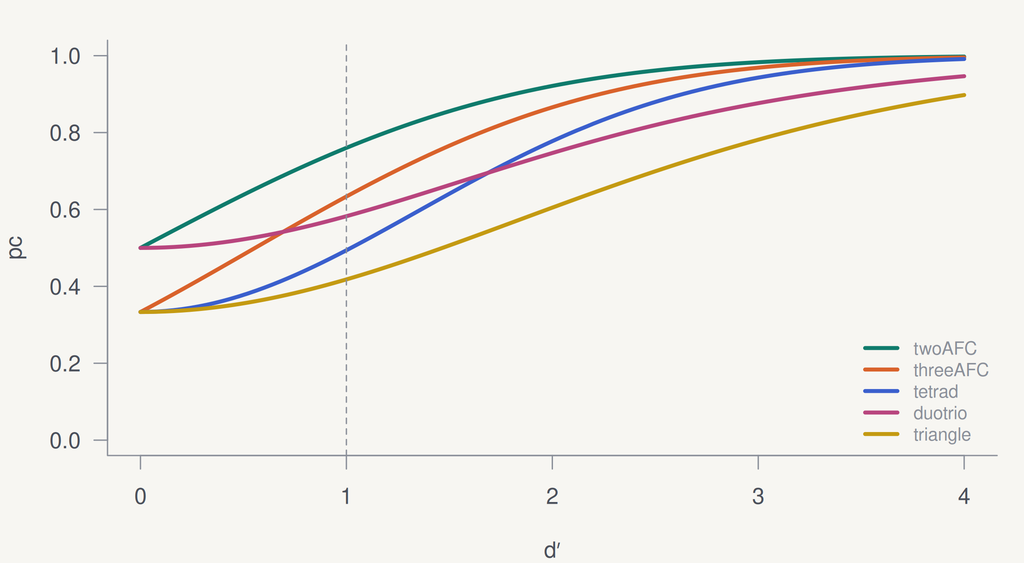

```r
methods <- c("twoAFC", "threeAFC", "tetrad",
             "duotrio", "triangle")
curve(psyfun(x, method = "twoAFC"), 0, 4,
      lwd = 3, col = pal[1], ylim = c(0, 1),
      xlab = "d′", ylab = "pc")
for (i in 2:5) curve(psyfun(x, method = methods[i]),
                     add = TRUE, lwd = 3, col = pal[i])
abline(v = 1, lty = 2)
legend("bottomright", methods, col = pal, lwd = 3,
       bty = "n", cex = 0.8)
```

```r
round(sapply(methods, function(m) psyfun(1, method = m)), 2)
```

```
  twoAFC threeAFC   tetrad  duotrio triangle
    0.76     0.63     0.49     0.58     0.42
```

## `discrim()` – from pc to d′

```r
discrim(42, 100, method = "triangle")
```

```
Estimates for the triangle discrimination protocol with 42 correct
answers in 100 trials. One-sided p-value and 95 % two-sided confidence
intervals are based on the 'exact' binomial test.

        Estimate Std. Error  Lower  Upper
pc         0.420    0.04936 0.3333 0.5229
pd         0.130    0.07403 0.0000 0.2843
d-prime    1.012    0.31377 0.0000 1.5849

Result of difference test:
'exact' binomial test:  p-value = 0.04337
Alternative hypothesis: d-prime is greater than 0
```

## Comparing two tests

```r
rbind(
  triangle = coef(discrim(42, 100, method = "triangle"))["d-prime", ],
  duotrio  = coef(discrim(36, 50, method = "duotrio"))["d-prime", ]
) |> round(2)
```

```
         Estimate Std. Error Lower Upper
triangle     1.01       0.31  0.00  1.58
duotrio      1.83       0.38  0.95  2.64
```

Duo-trio 36/50 (72%) corresponds to d′ = 1.83 – almost twice the difference of the triangle (d′ = 1.01). Without d′ we would not see this.

## Similarity test

When changing a supplier we want to show that the samples are **similar enough**.

```r
discrim(38, 100, method = "triangle", test = "similarity", pd0 = 0.2)$p.value
```

```
[1] 0.05017911
```

A non-significant difference test is **not** evidence of similarity. Similarity is tested with a limit pd₀ chosen in advance (e.g. at most 20% discriminators).

## QUIZ Difference or similarity?

You reduced sugar by 10% and want to keep “same taste” on the package. Which test?

**Similarity test** (`test = "similarity"`). A non-significant difference test would not support the claim – there might simply not have been enough assessors.

## Statistical power

|  | no difference | difference exists |
| --- | --- | --- |
| test significant | type I error α | **power 1 − β** |
| test not significant | correct | type II error β |

Power = the probability that the test detects a difference that really exists. We plan for at least **80%**.

## Power of the triangle by panel size

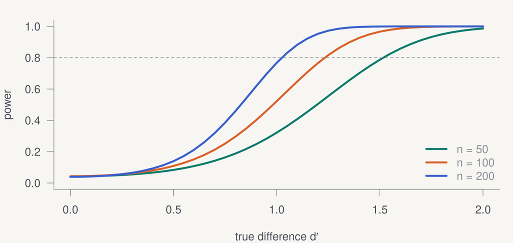

```r
d <- seq(0, 2, by = 0.05)
plot(NA, xlim = c(0, 2), ylim = c(0, 1), xlab = "true difference d′", ylab = "power")
for (i in 1:3) {
  n <- c(50, 100, 200)[i]
  lines(d, sapply(d, d.primePwr, sample.size = n, method = "triangle"), lwd = 3, col = pal[i])
}
abline(h = 0.8, lty = 2); legend("bottomright", c("n = 50", "n = 100", "n = 200"), col = pal[1:3], lwd = 3, bty = "n")
```

## How many assessors for d′ = 1?

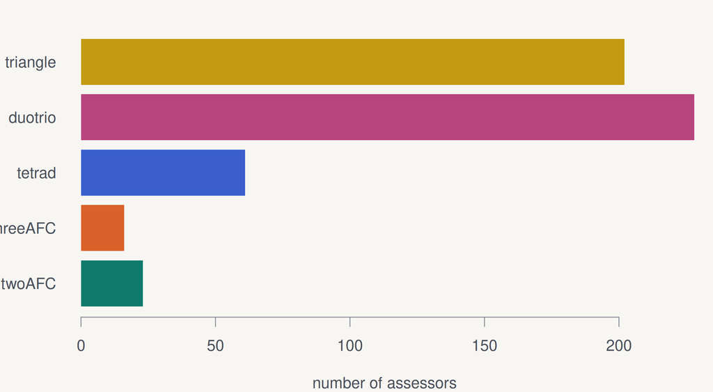

```r
n <- sapply(methods, function(m)
  d.primeSS(1, target.power = 0.8, method = m))
barplot(n, col = pal, border = NA, horiz = TRUE,
        las = 1, xlab = "number of assessors")
```

```r
n
```

```
  twoAFC threeAFC   tetrad  duotrio triangle
      23       16       61      228      202
```

## Answer for exercise 5a

Paired preference: 34 of 60 (57%), p = 0.37. If the preference really is 57%:

```r
pd <- 2 * 34 / 60 - 1
c(power_at_60 = discrimPwr(pd, sample.size = 60, pGuess = 1 / 2),
  required_n = discrimSS(pd, target.power = 0.8, pGuess = 1 / 2))
```

```
power_at_60  required_n
    0.25869   350.00000
```

With 60 people the test had only 26% power – a non-significant result was almost certain. About 350 consumers are needed for 80%.

## Scale data

```r
c(paired = power.t.test(delta = 0.5, sd = 1, power = 0.8, type = "paired")$n,
  two_groups = power.t.test(delta = 0.5, sd = 1, power = 0.8)$n) |> ceiling()
```

```
    paired two_groups
        34         64
```

The same difference of 0.5 points: a paired design needs 34 assessors, two independent groups 2 × 64. **Let everyone rate all samples** whenever possible.

## Summary

- **d′** is a method-independent measure of difference; pc and pd depend on the test.
- Similarity is shown with a **similarity test**, not with a non-significant difference test.
- Plan the panel size **before** the experiment: difference, α, 80% power.
- Sensitive methods (2-AFC, tetrad) save assessors.

Theory 13 Theory 14